# Coursework Report

*N* removed NAs: 2

*N* removed typo: 1

[output not shown]

**Main analysis results**

[interactive chart not shown]

[figure not shown]

[interactive chart not shown]

# Coursework Report

Analysing Data, Spring 2020

```
## tibble [150 x 6] (S3: tbl_df/tbl/data.frame)
##  $ id_code  : Factor w/ 150 levels "AAXF","AFGV",..: 99 5 63 33 143 137 32 10 31 8 ...
##  $ age_years: chr [1:150] "16" "20" "19" "23" ...
##  $ condition: Factor w/ 3 levels "contol","control",..: 2 2 2 2 2 2 2 2 2 2 ...
##  $ item_1   : num [1:150] 7 6 6 9 6 7 8 7 5 6 ...
##  $ item_2   : num [1:150] 8 5 6 8 7 6 9 7 6 8 ...
##  $ item_3   : num [1:150] 8 7 6 8 8 6 9 8 4 4 ...
```

```
## .
## 14 15 16 17 18 19 1w  2 20 21 22 23 24 25 26 27  6
##  2  1  7  5 13 21  1  1 21 18 19  9 10 10  6  3  1
```

```
## [1] "numeric"
```

```
## tibble [150 x 6] (S3: tbl_df/tbl/data.frame)
##  $ id_code  : Factor w/ 150 levels "AAXF","AFGV",..: 99 5 63 33 143 137 32 10 31 8 ...
##  $ age_years: num [1:150] 21 20 19 23 21 18 20 18 22 25 ...
##  $ condition: Factor w/ 3 levels "contol","control",..: 2 2 2 2 2 2 2 2 2 2 ...
##  $ item_1   : num [1:150] 7 6 6 9 6 7 8 7 5 6 ...
##  $ item_2   : num [1:150] 8 5 6 8 7 6 9 7 6 8 ...
##  $ item_3   : num [1:150] 8 7 6 8 8 6 9 8 4 4 ...
```

```
## .
## 18 19 20 21 22 23 24 25 26 27
## 13 21 21 36 19  9 10 10  6  3
```

```
## [1] 2
```

```
## # A tibble: 1 x 4
##    mean    sd   min   max
##   <dbl> <dbl> <dbl> <dbl>
## 1  21.4  2.28    18    27
```

```
## # A tibble: 1 x 4
##    mean    sd   min   max
##   <dbl> <dbl> <dbl> <dbl>
## 1  6.63  1.43     2     9
```

```
## # A tibble: 1 x 4
##    mean    sd   min   max
##   <dbl> <dbl> <dbl> <dbl>
## 1  6.65  1.51     3     9
```

```
## # A tibble: 1 x 4
##    mean    sd   min   max
##   <dbl> <dbl> <dbl> <dbl>
## 1  6.54  1.52     2     9
```

| condition | n | perc | mean_age | sd_age |
| --- | --- | --- | --- | --- |
| control | 76 | 51.35135 | 21.42105 | 2.137058 |
| experimental | 72 | 48.64865 | 21.29167 | 2.440489 |

Table 1 *Descriptive statistics by condition*

| condition | *N* | % | *M*<sub>age</sub> | *SD*<sub>age</sub> |
| --- | --- | --- | --- | --- |
| control | 76 | 51.35 | 21.42 | 2.14 |
| experimental | 72 | 48.65 | 21.29 | 2.44 |

```
## # A tibble: 2 x 5
##   condition        n  perc mean_age sd_age
##   <fct>        <int> <dbl>    <dbl>  <dbl>
## 1 control         76  51.4     21.4   2.14
## 2 experimental    72  48.6     21.3   2.44
```

| condition | mean_item_1 | sd_item_1 | mean_item_2 | sd_item_2 | mean_item_3 | sd_item_3 |
| --- | --- | --- | --- | --- | --- | --- |
| control | 6.302632 | 1.487904 | 6.250000 | 1.479865 | 6.078947 | 1.647326 |
| experimental | 6.972222 | 1.277897 | 7.069444 | 1.437196 | 7.027778 | 1.209961 |

Table 2 *Item descriptive statistics by condition*

| condition | mean(item 1) | SD(item 1) | mean(item 2) | SD(item 2) | mean(item 3) | SD(item 3) |
| --- | --- | --- | --- | --- | --- | --- |
| control | 6.30 | 1.49 | 6.25 | 1.48 | 6.08 | 1.65 |
| experimental | 6.97 | 1.28 | 7.07 | 1.44 | 7.03 | 1.21 |

```
## # A tibble: 2 x 7
##   condition    mean_item_1 sd_item_1 mean_item_2 sd_item_2 mean_item_3 sd_item_3
##   <fct>              <dbl>     <dbl>       <dbl>     <dbl>       <dbl>     <dbl>
## 1 control             6.30      1.49        6.25      1.48        6.08      1.65
## 2 experimental        6.97      1.28        7.07      1.44        7.03      1.21
```

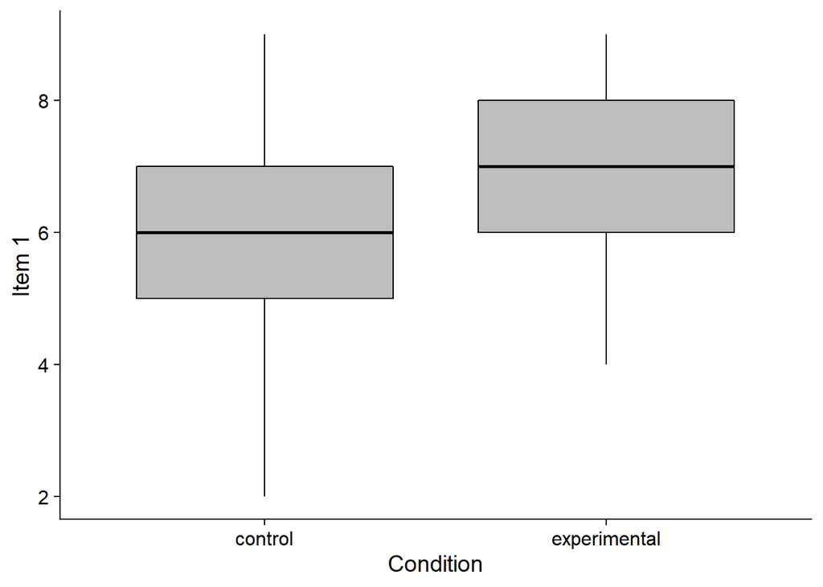

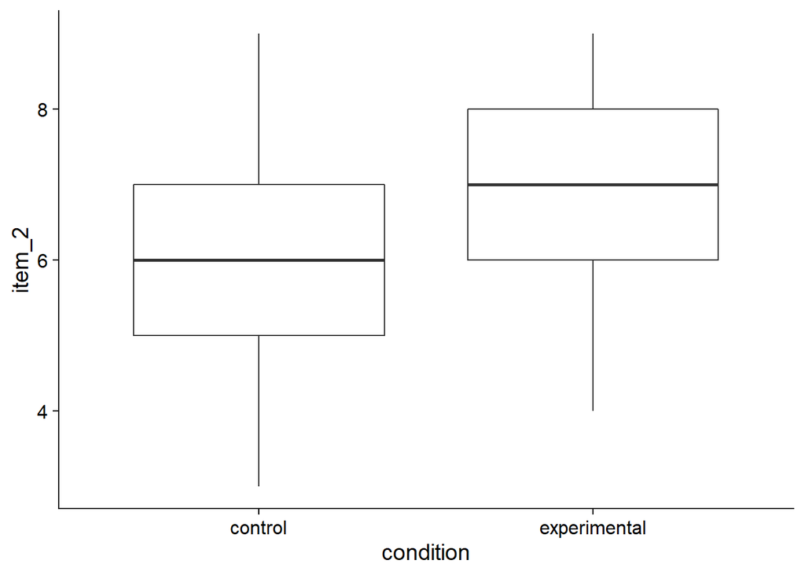

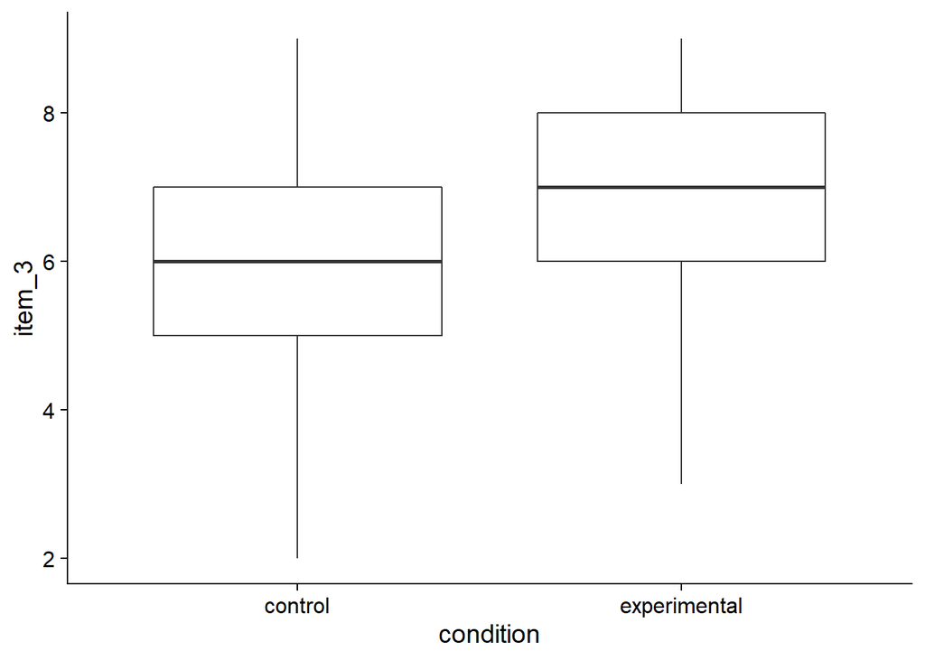

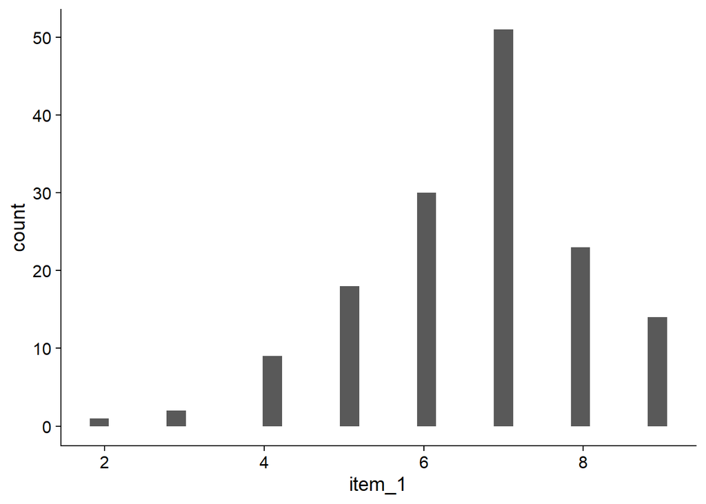

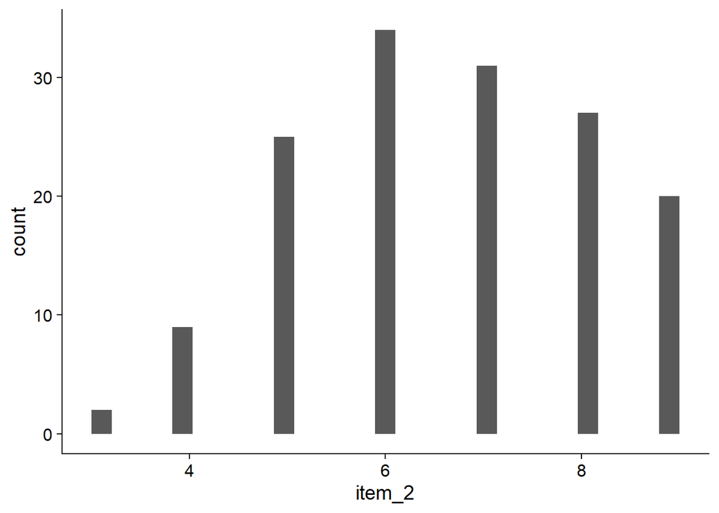

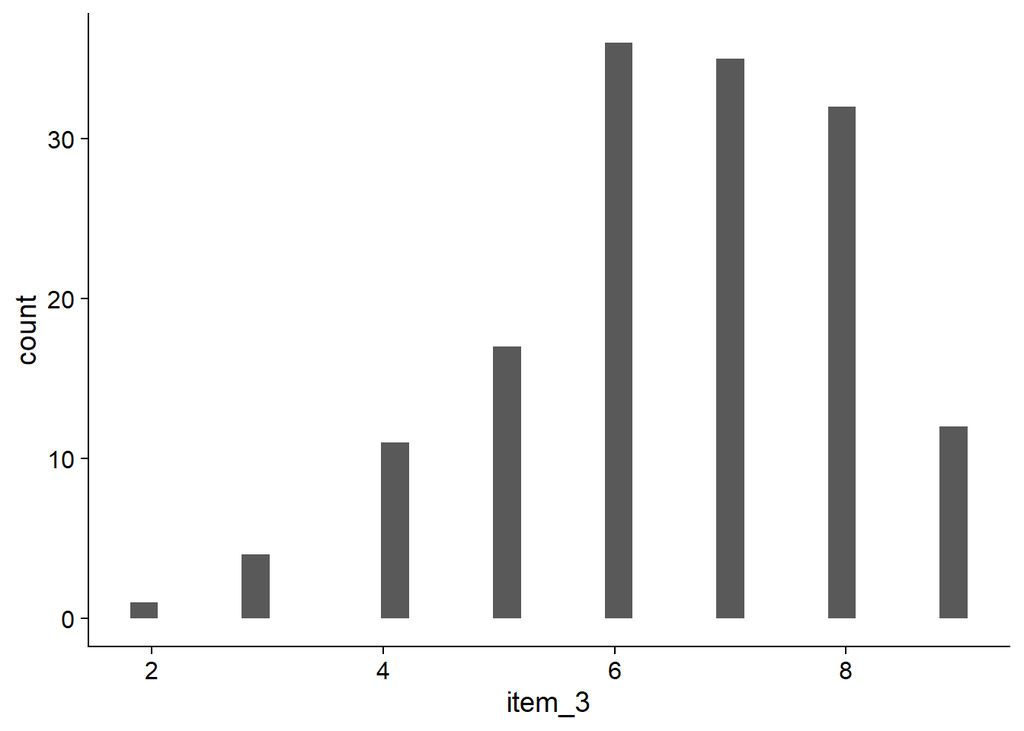

```
##
##  Two Sample t-test
##
## data:  item_1 by condition
## t = -2.9297, df = 146, p-value = 0.003939
## alternative hypothesis: true difference in means is not equal to 0
## 95 percent confidence interval:
##  -1.121297 -0.217884
## sample estimates:
##      mean in group control mean in group experimental
##                   6.302632                   6.972222
```

```
##
##  Two Sample t-test
##
## data:  item_2 by condition
## t = -3.4145, df = 146, p-value = 0.0008275
## alternative hypothesis: true difference in means is not equal to 0
## 95 percent confidence interval:
##  -1.2937482 -0.3451407
## sample estimates:
##      mean in group control mean in group experimental
##                   6.250000                   7.069444
```

```
##
##  Two Sample t-test
##
## data:  item_3 by condition
## t = -3.9756, df = 146, p-value = 0.00011
## alternative hypothesis: true difference in means is not equal to 0
## 95 percent confidence interval:
##  -1.4205090 -0.4771518
## sample estimates:
##      mean in group control mean in group experimental
##                   6.078947                   7.027778
```

# Methods

## Design

The research question being studied was whether or not the colour red changes a woman’s perception of a man’s physical attractiveness. Participants viewed a black-and-white photo of a man on either a red or white background, and rated how physically attractive they were on a 9-point scale. The independent variable in this experiment was the colour of the background of which the photo was on, so either red or white. The dependent variables were the women’s ratings of physical attractiveness. In order to measure this, the participants were asked 3 survey questions: “How attractive do you think this person is?”, “How pleasant is this person to look at?” and “If I were to meet the person in this picture face-to-face, I would think he is attractive”. The ratings of physical attractiveness were scored on a 9-point scale, 1 being not at all attractive and 9 being extremely attractive. The higher the score, the more physically attractive the male was perceived to be.

# Results

All 3 items generated very similar results for the experimental group with item 1 producing a mean of 6.97, item 2 was 7.07 and item 3 being 7.03. The results for the control condition were also extremely similar, with each item’s mean response being around 6. This is because the 3 questions for each item were all very similar just worded differently, so evidently produced similar results. The composite score for the experimental condition was 7.01, and for the control condition the composite score was 6.2, illustrating that overall the colour red in the experimental condition had a significant impact on attractiveness ratings.

I wanted to know whether the background colour of the photograph had any significant impact on attractiveness ratings, so ran an independent measures T-test in order to see if there was a significant difference between the 2 groups. The responses for item 1 - “How attractive do you think this person is?” - was significantly larger for the experimental group than for the control group. As the p value is small, we can conclude that the mean of the experimental group is larger than that for the control group. The same also applies for item 2 and item 3. This signifies that the red background did in fact increase participants’ attractiveness ratings for the male in the photograph, therefore the colour red has a significant impact on perceived attractiveness. A small p value means there is a very small chance that responses between the experimental and control group are equal, thus there is a large difference in responses between both groups.

# Discussion

This study aimed to find an answer to the question, “Does the colour red increase women’s perceived attractiveness of men?” by placing black and white photographs of men on either a white or red background; the control group being the white background and the experimental group being the red background. A significant difference was found between both groups, as the results illustrated that women rated men as more attractive when their photograph was on a red background. This clearly answers the research question, that yes, the colour red does increase women’s perceived attractiveness of men.

The results in this particular study are supported by a number of other studies that have also investigated the link between the colour red and perceived attractiveness. Guéguen (2010) found that male drivers were more likely to stop for female hitchhikers if they were wearing a red t-shirt, than any other colour. This was due to the fact that men were more physically attracted to women when associated with the colour red, further supporting the hypothesis from this study that red increases perceived physical attractiveness. Whether this would have been true for female drivers, we cannot be sure, however it still supports the main assumption that red is associated with higher ratings of physical attraction. On the other hand, Hesslinger, Goldbach and Carbon (2015) carried out a close replication of the current study (Elliot et al., 2010), however apparel style was manipulated along with the colour of the clothing. They found no significant effect of colour on perceived attractiveness, only of apparel style. This leads us to question the validity of our results, and whether or not they are replicable. Pazda, Elliot and Greitemeyer (2013) also carried out a partial replication of the current study, using the same 9-point scale of perceived attractiveness as Elliot et al. (2010). Contrastingly, the results from this study revealed increased perceived fashionableness and sexual receptivity, which in turn lead to an increased perception of physical attractiveness of women.

The results from the current and previous studies tend to suggest that red does in fact increase perceived attractiveness. However, they usually only focus on women’s perceived attractiveness of men or vice versa. There appears to be a lack of research which gives an answer to this question regarding both men and women. Future studies could aim to explore further into whether men and women have the same reactions to the colour red. Furthermore, in most research studies on this topic, researchers tend to solely use self-report measures, such as the 9-point scale in Elliot’s (2010) study, which is not the most accurate way of measuring this. In the future, researchers could also focus on physiological responses, for example whether or not participants experience increased heart rate when shown a photograph of a man on a red background. This way, it could eliminate the potential problem of demand characteristics which can arise when using self-report measures.

Another potential limitation of this study is that it lacks ecological validity, as ratings of attractiveness were only based on photographs of men which is considerably different to real life. Also, for most individuals, other factors contribute to finding someone attractive, such as their personality and voice. One way to tackle this issue could be to do an experiment in speed dating, in which participants have a 5 minute date with a confederate, some wearing red t-shirts, others wearing a neutral coloured t-shirt. Despite this being more time-consuming, it would be more meaningful and applicable to real life.

The results from this study, and previous studies in the same area of research, provide a strong bed of evidence to support the hypothesis that the colour red does increase perceived physical attractiveness. The results from this particular data set illustrate that women find men significantly more attractive if they are placed on a red background. The mean values of all 3 items support the general hypothesis, and so does the statistical test which produced a small p value, demonstrating that the mean of the experimental group was significantly higher than that of the control group. These results are further supported by those of other studies which generally tend to find a similar pattern, and a strong link between red and higher perceived physical attractiveness. Future studies could aim to focus more on the effect of red on both women and men’s perceived attractiveness, and comparisons between the two. Future research can also aim to make studies more applicable to real life settings.

# References

Elliot, A., Niesta Kayser, D., Greitemeyer, T., Lichtenfeld, S., Gramzow, R., Maier, M., & Liu, H. (2010). Red, rank, and romance in women viewing men. Journal Of Experimental Psychology: General, 139(3), 399-417. doi: 10.1037/a0019689

Guéguen, N. (2010). Color and women hitchhikers’ attractiveness: Gentlemen drivers prefer red. Color Research & Application, 37(1), 76-78. doi: 10.1002/col.20651

Hesslinger, V., Goldbach, L., & Carbon, C. (2015). Men in red: A reexamination of the red-attractiveness effect. Psychonomic Bulletin & Review, 22(4), 1142-1148. doi: 10.3758/s13423-015-0866-8

Pazda, A., Elliot, A., & Greitemeyer, T. (2013). Perceived sexual receptivity and fashionableness: Separate paths linking red and black to perceived attractiveness. Color Research & Application, 39(2), 208-212. doi: 10.1002/col.21804